# DS_project

Zicheng Yan

2024-05-07

load packages

```r
library(dplyr)
library(TTR)
library(randomForest)
library(lubridate)
```

```r
library(tree)
library(ggplot2)
library(keras)
library(skimr)
library(GGally)
library(corrplot)
library(tidyverse)
library(ROSE)
library(caret)
library(synthpop)
library(pROC)
library(e1071)
library(rpart)
library(rpart.plot)
library(xgboost)
#install.packages("doParallel")
library(doParallel)
numCores <- detectCores()
cl <- makeCluster(numCores - 1) # Leave one core free
registerDoParallel(cl)
```

read the dataset

```r
data.bank = read.csv("~/jhu/DS project/bank-additional-full.csv", sep=";")
```

Overview of the data

```r
summary(data.bank)
```

```
##       age            job              marital           education
##  Min.   :17.00   Length:41188       Length:41188       Length:41188
##  1st Qu.:32.00   Class :character   Class :character   Class :character
##  Median :38.00   Mode  :character   Mode  :character   Mode  :character
##  Mean   :40.02
##  3rd Qu.:47.00
##  Max.   :98.00
##    default            housing              loan             contact
##  Length:41188       Length:41188       Length:41188       Length:41188
##  Class :character   Class :character   Class :character   Class :character
##  Mode  :character   Mode  :character   Mode  :character   Mode  :character
##
##
##
##     month           day_of_week           duration         campaign
##  Length:41188       Length:41188       Min.   :   0.0   Min.   : 1.000
##  Class :character   Class :character   1st Qu.: 102.0   1st Qu.: 1.000
##  Mode  :character   Mode  :character   Median : 180.0   Median : 2.000
##                                        Mean   : 258.3   Mean   : 2.568
##                                        3rd Qu.: 319.0   3rd Qu.: 3.000
##                                        Max.   :4918.0   Max.   :56.000
##      pdays          previous       poutcome          emp.var.rate
##  Min.   :  0.0   Min.   :0.000   Length:41188       Min.   :-3.40000
##  1st Qu.:999.0   1st Qu.:0.000   Class :character   1st Qu.:-1.80000
##  Median :999.0   Median :0.000   Mode  :character   Median : 1.10000
##  Mean   :962.5   Mean   :0.173                      Mean   : 0.08189
##  3rd Qu.:999.0   3rd Qu.:0.000                      3rd Qu.: 1.40000
##  Max.   :999.0   Max.   :7.000                      Max.   : 1.40000
##  cons.price.idx  cons.conf.idx     euribor3m      nr.employed
##  Min.   :92.20   Min.   :-50.8   Min.   :0.634   Min.   :4964
##  1st Qu.:93.08   1st Qu.:-42.7   1st Qu.:1.344   1st Qu.:5099
##  Median :93.75   Median :-41.8   Median :4.857   Median :5191
##  Mean   :93.58   Mean   :-40.5   Mean   :3.621   Mean   :5167
##  3rd Qu.:93.99   3rd Qu.:-36.4   3rd Qu.:4.961   3rd Qu.:5228
##  Max.   :94.77   Max.   :-26.9   Max.   :5.045   Max.   :5228
##       y
##  Length:41188
##  Class :character
##  Mode  :character
##
##
##
```

Skim for a detailed summary

```r
skim(data.bank)
```

Data summary

| Name | data.bank |
| --- | --- |
| Number of rows | 41188 |
| Number of columns | 21 |
| _______________________ |  |
| Column type frequency: |  |
| character | 11 |
| numeric | 10 |
| ________________________ |  |
| Group variables | None |

**Variable type: character**

| skim_variable | n_missing | complete_rate | min | max | empty | n_unique | whitespace |
| --- | --- | --- | --- | --- | --- | --- | --- |
| job | 0 | 1 | 6 | 13 | 0 | 12 | 0 |
| marital | 0 | 1 | 6 | 8 | 0 | 4 | 0 |
| education | 0 | 1 | 7 | 19 | 0 | 8 | 0 |
| default | 0 | 1 | 2 | 7 | 0 | 3 | 0 |
| housing | 0 | 1 | 2 | 7 | 0 | 3 | 0 |
| loan | 0 | 1 | 2 | 7 | 0 | 3 | 0 |
| contact | 0 | 1 | 8 | 9 | 0 | 2 | 0 |
| month | 0 | 1 | 3 | 3 | 0 | 10 | 0 |
| day_of_week | 0 | 1 | 3 | 3 | 0 | 5 | 0 |
| poutcome | 0 | 1 | 7 | 11 | 0 | 3 | 0 |
| y | 0 | 1 | 2 | 3 | 0 | 2 | 0 |

**Variable type: numeric**

| skim_variable | n_missing | complete_rate | mean | sd | p0 | p25 | p50 | p75 | p100 | hist |
| --- | --- | --- | --- | --- | --- | --- | --- | --- | --- | --- |
| age | 0 | 1 | 40.02 | 10.42 | 17.00 | 32.00 | 38.00 | 47.00 | 98.00 | ▅▇▃▁▁ |
| duration | 0 | 1 | 258.29 | 259.28 | 0.00 | 102.00 | 180.00 | 319.00 | 4918.00 | ▇▁▁▁▁ |
| campaign | 0 | 1 | 2.57 | 2.77 | 1.00 | 1.00 | 2.00 | 3.00 | 56.00 | ▇▁▁▁▁ |
| pdays | 0 | 1 | 962.48 | 186.91 | 0.00 | 999.00 | 999.00 | 999.00 | 999.00 | ▁▁▁▁▇ |
| previous | 0 | 1 | 0.17 | 0.49 | 0.00 | 0.00 | 0.00 | 0.00 | 7.00 | ▇▁▁▁▁ |
| emp.var.rate | 0 | 1 | 0.08 | 1.57 | -3.40 | -1.80 | 1.10 | 1.40 | 1.40 | ▁▃▁▁▇ |
| cons.price.idx | 0 | 1 | 93.58 | 0.58 | 92.20 | 93.08 | 93.75 | 93.99 | 94.77 | ▁▆▃▇▂ |
| cons.conf.idx | 0 | 1 | -40.50 | 4.63 | -50.80 | -42.70 | -41.80 | -36.40 | -26.90 | ▅▇▁▇▁ |
| euribor3m | 0 | 1 | 3.62 | 1.73 | 0.63 | 1.34 | 4.86 | 4.96 | 5.04 | ▅▁▁▁▇ |
| nr.employed | 0 | 1 | 5167.04 | 72.25 | 4963.60 | 5099.10 | 5191.00 | 5228.10 | 5228.10 | ▁▁▃▁▇ |

Check for missing values

```r
sum(is.na(data.bank))
```

```
## [1] 0
```

Visualize correlations between numerical features

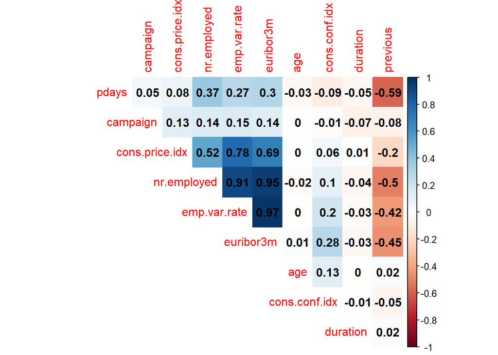

```r
numeric_data = data.bank %>% select_if(is.numeric)
cor_matrix = cor(numeric_data, use = "complete.obs")
corrplot(cor_matrix, method = "color", type = "upper", order = "hclust",
         addCoef.col = "black",  # Add correlation coefficients to the plot
         diag = FALSE)  # Do not show diagonal
```

Strong correlation detected between nr.employed, euribor3m, and emp.var.rate. This issue will be handled later with PCA.

The categorical variables are in type ‘chr’ instead of ‘factor’, which needs to be corrected

```r
categorical_data <- data.bank %>%
  select_if(~is.character(.)) %>%
  pivot_longer(cols = everything(), names_to = "variable", values_to = "value")

categorical_columns <- c("job",
"marital",
"education",
"default",
"housing",
"loan",
"contact",
"month",
"day_of_week",
"poutcome",
"y")
data.bank[categorical_columns] <- lapply(data.bank[categorical_columns], factor)
```

We will dummy code categorical variables with 3 or less categories and encode the rest. Although for tree based model this isn’t necessary, we plan to apply other models like RNN and logistic regression.

```r
data <- data.bank

# Separate variables based on the number of categories
variables_to_dummy <- names(which(sapply(data, function(x) is.factor(x) && length(levels(x)) <= 3)))
variables_to_encode <- names(which(sapply(data, function(x) is.factor(x) && length(levels(x)) > 3)))

# Apply dummy coding to variables with 3 or fewer categories using dummyVars
dummy_vars <- dummyVars(~ ., data = data[, variables_to_dummy], fullRank = FALSE)
data_dummies <- predict(dummy_vars, newdata = data)

# Integrate dummies back into the main dataset
data <- cbind(data[, !(names(data) %in% variables_to_dummy)], data_dummies)

# For variables with more than 3 categories, apply integer encoding
data[, variables_to_encode] <- lapply(data[, variables_to_encode], function(x) as.integer(as.factor(x)))


# Check the transformed data structure
str(data)
```

```
## 'data.frame':    41188 obs. of  31 variables:
##  $ age                 : int  56 57 37 40 56 45 59 41 24 25 ...
##  $ job                 : int  4 8 8 1 8 8 1 2 10 8 ...
##  $ marital             : int  2 2 2 2 2 2 2 2 3 3 ...
##  $ education           : int  1 4 4 2 4 3 6 8 6 4 ...
##  $ month               : int  7 7 7 7 7 7 7 7 7 7 ...
##  $ day_of_week         : int  2 2 2 2 2 2 2 2 2 2 ...
##  $ duration            : int  261 149 226 151 307 198 139 217 380 50 ...
##  $ campaign            : int  1 1 1 1 1 1 1 1 1 1 ...
##  $ pdays               : int  999 999 999 999 999 999 999 999 999 999 ...
##  $ previous            : int  0 0 0 0 0 0 0 0 0 0 ...
##  $ emp.var.rate        : num  1.1 1.1 1.1 1.1 1.1 1.1 1.1 1.1 1.1 1.1 ...
##  $ cons.price.idx      : num  94 94 94 94 94 ...
##  $ cons.conf.idx       : num  -36.4 -36.4 -36.4 -36.4 -36.4 -36.4 -36.4 -36.4 -36.4 -36.4 ...
##  $ euribor3m           : num  4.86 4.86 4.86 4.86 4.86 ...
```

[output cut: 17 more lines]

```r
data = data%>% select(-y.no)
data = data%>% rename(y = y.yes)
str(data)
```

```
## 'data.frame':    41188 obs. of  30 variables:
##  $ age                 : int  56 57 37 40 56 45 59 41 24 25 ...
##  $ job                 : int  4 8 8 1 8 8 1 2 10 8 ...
##  $ marital             : int  2 2 2 2 2 2 2 2 3 3 ...
##  $ education           : int  1 4 4 2 4 3 6 8 6 4 ...
##  $ month               : int  7 7 7 7 7 7 7 7 7 7 ...
##  $ day_of_week         : int  2 2 2 2 2 2 2 2 2 2 ...
##  $ duration            : int  261 149 226 151 307 198 139 217 380 50 ...
##  $ campaign            : int  1 1 1 1 1 1 1 1 1 1 ...
##  $ pdays               : int  999 999 999 999 999 999 999 999 999 999 ...
##  $ previous            : int  0 0 0 0 0 0 0 0 0 0 ...
##  $ emp.var.rate        : num  1.1 1.1 1.1 1.1 1.1 1.1 1.1 1.1 1.1 1.1 ...
##  $ cons.price.idx      : num  94 94 94 94 94 ...
##  $ cons.conf.idx       : num  -36.4 -36.4 -36.4 -36.4 -36.4 -36.4 -36.4 -36.4 -36.4 -36.4 ...
##  $ euribor3m           : num  4.86 4.86 4.86 4.86 4.86 ...
```

[output cut: 16 more lines]

Plotting the distribution of cat vars

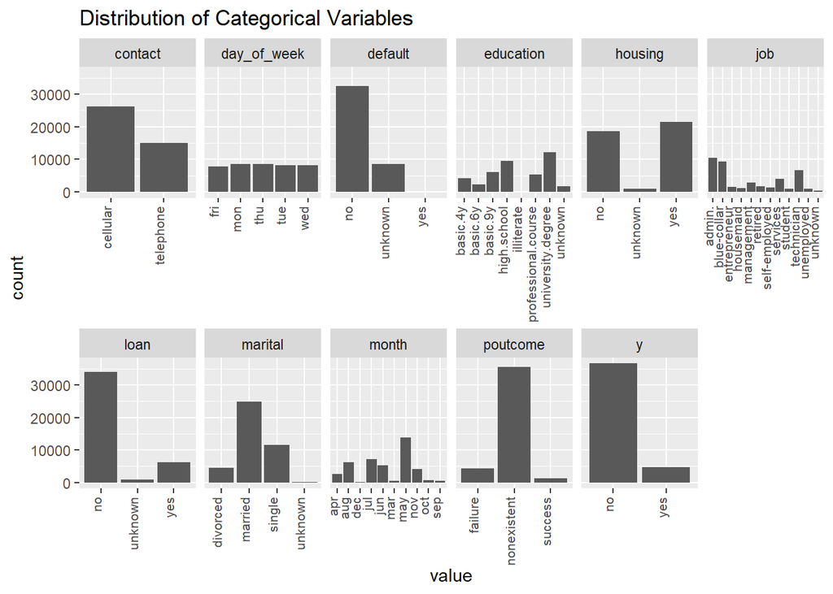

```r
ggplot(categorical_data, aes(x = value)) +
  geom_bar() +
  facet_wrap(~ variable, scales = "free_x", nrow = 2) +
  theme(axis.text.x = element_text(angle = 90, hjust = 1, vjust = 0, size = 8)) +
  labs(title = "Distribution of Categorical Variables")
```

We can easily notice that this dataset is not very balanced on target variable y. Since we don’t want to lose too much data, we decided to use a combination of over and under sampling.

We also considered data implementation technique like SMOTE, but given that we have a large portion of categorical variables, it probably won’t work well.

Taking a look into the features

Start with a quick rf model to tell feature importance and serve as benchmark model

```r
rf_model <- randomForest(y ~ ., data = data.bank, ntree = 500, importance = TRUE)
print(rf_model)
```

```
##
## Call:
##  randomForest(formula = y ~ ., data = data.bank, ntree = 500,      importance = TRUE)
##                Type of random forest: classification
##                      Number of trees: 500
## No. of variables tried at each split: 4
##
##         OOB estimate of  error rate: 8.47%
## Confusion matrix:
##        no  yes class.error
## no  35225 1323  0.03619897
## yes  2166 2474  0.46681034
```

```r
importance_scores <- importance(rf_model, type = 1)
print(importance_scores)
```

```
##                MeanDecreaseAccuracy
## age                      23.4442616
## job                      26.4962883
## marital                   6.6184286
## education                19.1491426
## default                   9.0022355
## housing                  -4.3148653
## loan                     -0.5570898
## contact                   9.7436931
## month                    26.5920013
## day_of_week              32.8439670
## duration                242.5276312
## campaign                 15.0059202
## pdays                    25.8932023
## previous                  9.0396769
## poutcome                 16.9426537
## emp.var.rate             19.0116754
## cons.price.idx           18.3897650
## cons.conf.idx            18.3497904
## euribor3m                32.3925698
## nr.employed              22.3994851
```

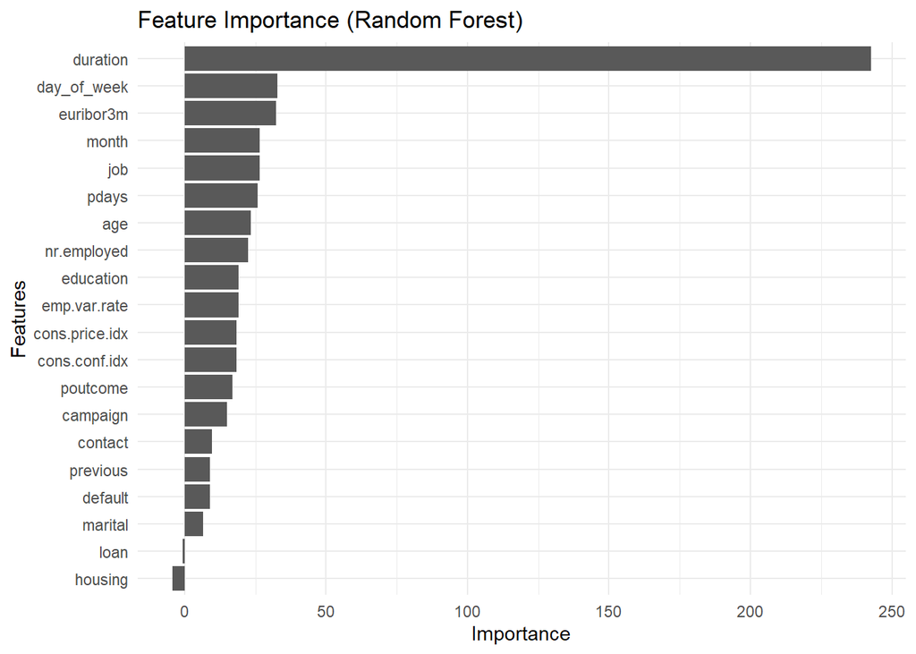

```r
importance_df <- data.frame(Feature = rownames(importance_scores), Importance = importance_scores[, "MeanDecreaseAccuracy"])

ggplot(importance_df, aes(x = reorder(Feature, Importance), y = Importance)) +
  geom_col() +
  coord_flip() +  # Flips the axes to make it easier to read
  labs(title = "Feature Importance (Random Forest)", x = "Features", y = "Importance") +
  theme_minimal()
```

A feature with negative importance! This is rare. We should carefully consider whether to drop it

The variable “duration” has shown the greatest importance, however, it stands for last contact duration (how many days since last call). Therefore, it is not known before a call is performed. Also, after the end of the call y is obviously known. Thus, it will be included only for this benchmark model since we want to have a realistic predictive model.

To conduct some real training, we need to perform train-test split before balancing to prevent any possible feature leakage.Feature engineering like PCA should also be done before the split.

```r
set.seed(42) # The Ultimate Answer to the Universe
data = data %>% select(-duration) # Dropping duration

# perform pca on these 3 features with strong correlation
pca_data <- data[, c("nr.employed", "euribor3m", "emp.var.rate")]
pca_result <- prcomp(pca_data, scale. = TRUE)
summary(pca_result)
```

```
## Importance of components:
##                           PC1     PC2     PC3
## Standard deviation     1.6980 0.31035 0.14323
## Proportion of Variance 0.9611 0.03211 0.00684
## Cumulative Proportion  0.9611 0.99316 1.00000
```

Based on the variance each component contains, we only need to keep PC1 and 2

```r
# Replace the 3 variables with PC1 and PC2
pc_scores <- pca_result$x
pc_scores <- pc_scores[, 1:2]
colnames(pc_scores) <- paste("PC", 1:2, sep="")
data <- data[, !names(data) %in% c("nr.employed", "euribor3m", "emp.var.rate")]
data <- cbind(data, pc_scores)
```

Standardization: since we plan to use models like SVM and RNN that are sensitive to the scale of data, we need to create a separated pipeline here for standardization.

```r
data_scaled <- as.data.frame(lapply(data[, -which(names(data) == "y")], scale))
data_scaled$target <- data$target
```

Next we perform train test split

```r
split <- createDataPartition(data$y, p = 0.75, list = FALSE)
train_set <- data[split, ]
test_set <- data[-split, ]
```

Print out the distribution of target class

```r
table(train_set$y)
```

```
##
##     0     1
## 27411  3480
```

Clearly the data set is imbalanced, so we will balance it with a combination of oversampling minority class and under sampling majority class, eventually reach a level that

majority : minority about 2 : 1

```r
train_balanced = ovun.sample(y ~ ., data = train_set, method = "both", N = 20000, p = 0.3)$data
table(train_balanced$y)
```

```
##
##     0     1
## 13973  6027
```

We decided to also try synthpop, a tool that can generate synthetic data for both numeric and categorical data types.It uses statistical modeling to predict each variable based on the others.

```r
synthetic_data = syn(train_set, seed = 42) # The ultimate answer of the universe
synthetic_minority_only = synthetic_data$syn[synthetic_data$syn$y == "1", ]
```

Remove some “no” observations so the resulting set has similar distribution

```r
indices_of_no <- which(train_set$y == "0")
indices_to_remove <- sample(indices_of_no, length(indices_of_no) / 2)
reduced_train_set <- train_set[-indices_to_remove, ]

train_syn <- rbind(reduced_train_set, synthetic_minority_only)
table(train_syn$y)
```

```
##
##     0     1
## 13706  7026
```

— End of Preprocessing (hopefully) —

— Modeling Starts Here —

— Logistic Model —

Let’s start with fitting a loigstic model on plain training set with no data balancing

```r
logit_model <- glm(y ~ ., data = train_set, family = binomial())
summary(logit_model)
```

```
##
## Call:
## glm(formula = y ~ ., family = binomial(), data = train_set)
##
## Coefficients: (5 not defined because of singularities)
##                        Estimate Std. Error z value Pr(>|z|)
## (Intercept)          -9.106e+11  3.448e+12  -0.264  0.79170
## age                   5.368e-03  1.923e-03   2.791  0.00525 **
## job                   1.968e-05  5.588e-03   0.004  0.99719
## marital               8.142e-02  3.630e-02   2.243  0.02490 *
## education             3.244e-02  9.928e-03   3.268  0.00108 **
## month                -5.199e-02  8.275e-03  -6.283 3.31e-10 ***
## day_of_week           6.211e-02  1.462e-02   4.249 2.15e-05 ***
## campaign             -5.036e-02  1.074e-02  -4.688 2.76e-06 ***
## pdays                -1.198e-03  2.266e-04  -5.288 1.24e-07 ***
## previous             -9.961e-02  6.372e-02  -1.563  0.11802
## cons.price.idx        1.078e+00  1.087e-01   9.919  < 2e-16 ***
## cons.conf.idx         5.509e-02  4.732e-03  11.642  < 2e-16 ***
## default.no            9.106e+11  3.448e+12   0.264  0.79170
## default.unknown       9.106e+11  3.448e+12   0.264  0.79170
## default.yes           9.106e+11  3.448e+12   0.264  0.79170
## housing.no            2.652e-02  4.101e-02   0.647  0.51778
## housing.unknown      -1.801e-02  1.436e-01  -0.125  0.90019
## housing.yes                  NA         NA      NA       NA
## loan.no               3.256e-02  5.702e-02   0.571  0.56799
## loan.unknown                 NA         NA      NA       NA
## loan.yes                     NA         NA      NA       NA
## contact.cellular      8.081e-01  6.524e-02  12.386  < 2e-16 ***
## contact.telephone            NA         NA      NA       NA
## poutcome.failure     -6.993e-01  2.214e-01  -3.159  0.00158 **
## poutcome.nonexistent -2.233e-01  2.216e-01  -1.008  0.31362
## poutcome.success             NA         NA      NA       NA
## PC1                   6.697e-01  2.572e-02  26.042  < 2e-16 ***
## PC2                  -5.008e-01  1.250e-01  -4.005 6.20e-05 ***
## ---
## Signif. codes:  0 '***' 0.001 '**' 0.01 '*' 0.05 '.' 0.1 ' ' 1
##
## (Dispersion parameter for binomial family taken to be 1)
##
##     Null deviance: 21749  on 30890  degrees of freedom
## Residual deviance: 17466  on 30868  degrees of freedom
## AIC: 17512
##
## Number of Fisher Scoring iterations: 25
```

But before evaluation let’s create a function for computing these metrics cause we are going to do this many times

```r
calculate_metrics <- function(confusionMatrix) {
  # Extract counts from the confusion matrix
  TP <- confusionMatrix[2, 2]
  TN <- confusionMatrix[1, 1]
  FP <- confusionMatrix[1, 2]
  FN <- confusionMatrix[2, 1]

  # Calculate accuracy
  accuracy <- (TP + TN) / sum(confusionMatrix)

  # Calculate False Positive Rate (FPR) and False Negative Rate (FNR)
  FPR <- FP / (FP + TN)
  FNR <- FN / (FN + TP)

  # Calculate precision and recall
  precision <- TP / (TP + FP)
  recall <- TP / (TP + FN)

  # Calculate F1 score
  F1 <- 2 * (precision * recall) / (precision + recall)

  # Create a data frame to neatly display the metrics
  metrics_df = data.frame(
    Metric = c("Accuracy", "False Positive Rate", "False Negative Rate", "Precision", "Recall", "F1 Score"),
    Value = c(accuracy, FPR, FNR, precision, recall, F1)
  )

  # Print the data frame as a table
  print(metrics_df, row.names = FALSE)
}
```

Make prediction with 0.5 cutoff to calculate accuracy and show confusion matrix

```r
test_set$predicted_prob <- predict(logit_model, newdata = test_set, type = "response")
test_set$predicted_class <- ifelse(test_set$predicted_prob > 0.5, 1, 0)
confusionMatrix <- table(test_set$y, test_set$predicted_class)

print(confusionMatrix)
```

```
##
##        0    1
##   0 9016  121
##   1  890  270
```

```r
# Call the function we just created
calculate_metrics(confusionMatrix)
```

```
##               Metric      Value
##             Accuracy 0.90181606
##  False Positive Rate 0.01324286
##  False Negative Rate 0.76724138
##            Precision 0.69053708
##               Recall 0.23275862
##             F1 Score 0.34816248
```

Though the accuracy is not bad, the F1 score is poor and the False Negative Rate is extremely high. Let’s see if this could be solved with more balanced data.

```r
logit_model_balanced <- glm(y ~ ., data = train_balanced, family = binomial())
#summary(logit_model_balanced)
logit_model_syn <- glm(y ~ ., data = train_syn, family = binomial())
#summary(logit_model_syn)
```

```r
test_set$predicted_prob <- predict(logit_model_balanced, newdata = test_set, type = "response")
# Yeah I know I should probably set up a new pointer for new predictions, but there are so many models
# and I really want to save some memory
test_set$predicted_class <- ifelse(test_set$predicted_prob > 0.5, 1, 0)
print("Result of using oversampled data")
```

```
## [1] "Result of using oversampled data"
```

```r
confusionMatrix <- table(test_set$y, test_set$predicted_class)
print(confusionMatrix)
```

```
##
##        0    1
##   0 8428  709
##   1  529  631
```

```r
calculate_metrics(confusionMatrix)
```

```
##               Metric      Value
##             Accuracy 0.87977081
##  False Positive Rate 0.07759659
##  False Negative Rate 0.45603448
##            Precision 0.47089552
##               Recall 0.54396552
##             F1 Score 0.50480000
```

```r
test_set$predicted_prob <- predict(logit_model_syn, newdata = test_set, type = "response")
test_set$predicted_class <- ifelse(test_set$predicted_prob > 0.5, 1, 0)
print("Result of using generated data")
```

```
## [1] "Result of using generated data"
```

```r
confusionMatrix <- table(test_set$y, test_set$predicted_class)
print(confusionMatrix)
```

```
##
##        0    1
##   0 8344  793
##   1  515  645
```

```r
calculate_metrics(confusionMatrix)
```

```
##               Metric      Value
##             Accuracy 0.87297271
##  False Positive Rate 0.08678997
##  False Negative Rate 0.44396552
##            Precision 0.44853964
##               Recall 0.55603448
##             F1 Score 0.49653580
```

```r
test_set$predicted_prob <- predict(logit_model_balanced, newdata = test_set, type = "response")
```

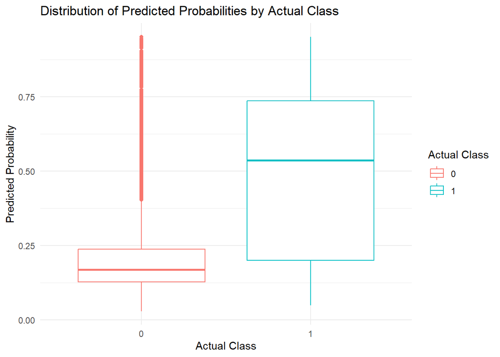

```r
ggplot(test_set, aes(x = as.factor(y), y = predicted_prob, colour = as.factor(y))) +
  geom_boxplot() +
  labs(title = "Distribution of Predicted Probabilities by Actual Class",
       x = "Actual Class",
       y = "Predicted Probability",
       colour = "Actual Class") +
  theme_minimal()
```

Looking at the predicted prob distribution, we realize that we might be able to “improve” the model performance by simply using a lower cutoff.

```r
test_set$predicted_prob <- predict(logit_model_balanced, newdata = test_set, type = "response")
test_set$predicted_class <- ifelse(test_set$predicted_prob > 0.48, 1, 0)
print("Result of using oversampled data")
```

```
## [1] "Result of using oversampled data"
```

```r
confusionMatrix <- table(test_set$y, test_set$predicted_class)
print(confusionMatrix)
```

```
##
##        0    1
##   0 8343  794
##   1  506  654
```

```r
calculate_metrics(confusionMatrix)
```

```
##               Metric      Value
##             Accuracy 0.87374964
##  False Positive Rate 0.08689942
##  False Negative Rate 0.43620690
##            Precision 0.45165746
##               Recall 0.56379310
##             F1 Score 0.50153374
```

```r
test_set$predicted_prob <- predict(logit_model_syn, newdata = test_set, type = "response")
test_set$predicted_class <- ifelse(test_set$predicted_prob > 0.48, 1, 0)
print("Result of using generated data")
```

```
## [1] "Result of using generated data"
```

```r
confusionMatrix <- table(test_set$y, test_set$predicted_class)
print(confusionMatrix)
```

```
##
##        0    1
##   0 8251  886
##   1  487  673
```

```r
calculate_metrics(confusionMatrix)
```

```
##               Metric      Value
##             Accuracy 0.86666019
##  False Positive Rate 0.09696837
##  False Negative Rate 0.41982759
##            Precision 0.43168698
##               Recall 0.58017241
##             F1 Score 0.49503494
```

We’ve tried 5 different cutoffs ranging from 0.48 to 0.32, none of them is able to improve the performance in terms of F1 score and accuracy. However, given the nature of the task: identifying user for marketing campaign, this decision threshold might be useful. It represents a trade-off between more cost (higher False Positive Rate) and more new subscription (False Negative Rate).

```r
log_roc_result <- roc(test_set$y, test_set$predicted_prob)
```

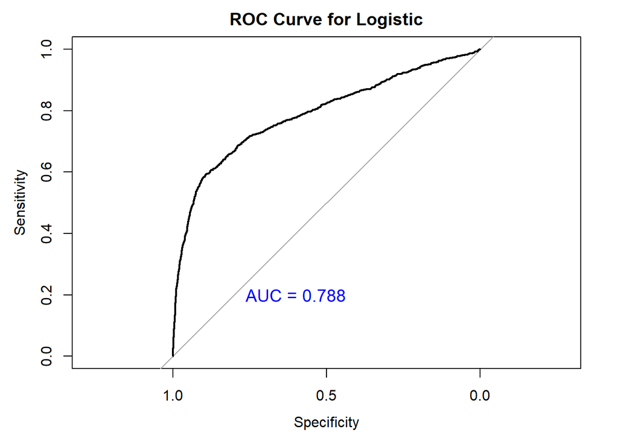

```r
log_auc_value <- auc(log_roc_result)
plot(log_roc_result, main = "ROC Curve for Logistic")
text(x = 0.6, y = 0.2, labels = paste("AUC =", round(log_auc_value, 3)), cex = 1.2, col = "blue")
```

— SVM Model —

For SVM we need standardization, so we need to continue work on data_scaled

```r
data_scaled$y = data$y
split <- createDataPartition(data_scaled$y, p = 0.75, list = FALSE)
train_set_scaled <- data_scaled[split, ]
test_set_scaled <- data_scaled[-split, ]

train_balanced_scaled = ovun.sample(y ~ ., data = train_set_scaled, method = "both", N = 20000, p = 0.3)$data
table(train_balanced_scaled$y)
```

```
##
##     0     1
## 13945  6055
```

Converting the type of y to factor, train on a SVM classifier

```r
train_balanced_scaled$y <- as.factor(train_balanced_scaled$y)
test_set_scaled$y <- as.factor(test_set_scaled$y)

svm_model <- svm(y ~ ., data = train_balanced_scaled, kernel = "radial", cost = 1, scale = FALSE)
print(svm_model)
```

```
##
## Call:
## svm(formula = y ~ ., data = train_balanced_scaled, kernel = "radial",
##     cost = 1, scale = FALSE)
##
##
## Parameters:
##    SVM-Type:  C-classification
##  SVM-Kernel:  radial
##        cost:  1
##
## Number of Support Vectors:  9570
```

```r
test_set_scaled$predicted <- predict(svm_model, test_set_scaled, type = "response")
confusionMatrix <- table(Predicted = test_set_scaled$predicted, Actual = test_set_scaled$y)
print(confusionMatrix)
```

```
##          Actual
## Predicted    0    1
##         0 8360  572
##         1  740  625
```

```r
calculate_metrics(confusionMatrix)
```

```
##               Metric      Value
##             Accuracy 0.87258425
##  False Positive Rate 0.06403941
##  False Negative Rate 0.54212454
##            Precision 0.52213868
##               Recall 0.45787546
##             F1 Score 0.48790008
```

The performance is basically the same as logistic model, let’s see if we can make it better with fine-tuning It’s taking incredibly long so we commented this part.

```r
# Set up the parameter grid
# tune_result <- tune(svm, train.x = y ~ ., data = train_balanced_scaled,
#                     kernel = "radial", scale = FALSE, cross = 2,
#                     ranges = list(cost = 10^(-1:1), gamma = 10^(-2:0)))
#
# # Print the best model found
# print(tune_result$best.model)
```

— Decision Tree —

Build a decision tree model for interpretability

Since tree-based models are not sensitive to scale and accept factor type features, we only need to address the extreme data imbalance.

```r
data_tree = data.bank %>% select(-duration)
split <- createDataPartition(data_tree$y, p = 0.75, list = FALSE)
train_tree <- data_tree[split, ]
test_tree <- data_tree[-split, ]

train_tree = ovun.sample(y ~ ., data = train_tree, method = "both", N = 20000, p = 0.3)$data
table(train_tree$y)
```

```
##
##    no   yes
## 13952  6048
```

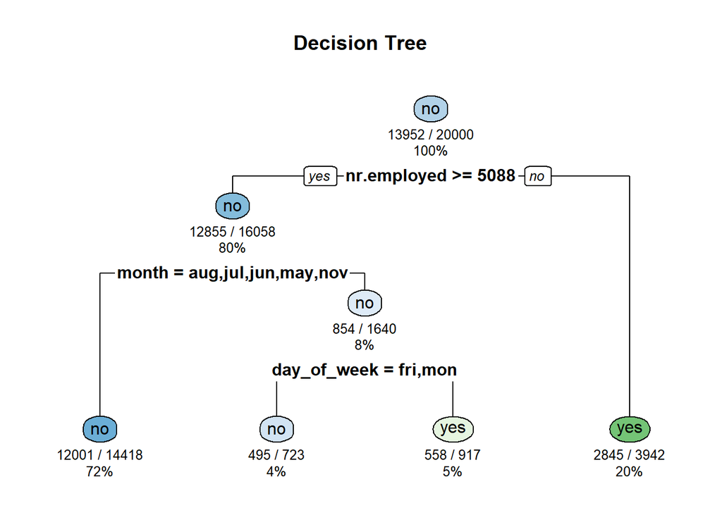

```r
decision_tree_model <- rpart(y ~ ., data = train_tree, method = "class")
rpart.plot(decision_tree_model, main="Decision Tree", extra=102, under=TRUE, faclen=0)
```

This is interesting… The decision tree graph shows the single most important factor is nr.employed, which is a economic context indicator, the number of employees. So probably the bank should consider only conduct direct marketing campaigns when the economy is cooling, specifically, when the quarterly newly employed number is less than 5088.

```r
importance <- as.data.frame(varImp(decision_tree_model, scale=FALSE))
print(importance)
```

```
##                   Overall
## cons.conf.idx   247.04832
## cons.price.idx  207.22031
## day_of_week      69.48377
## default          39.90553
## emp.var.rate   1523.89903
## euribor3m      1816.43334
## job              48.48370
## month           337.53656
## nr.employed    1726.49640
## pdays           979.22382
## poutcome        913.35709
## age               0.00000
## marital           0.00000
## education         0.00000
## housing           0.00000
## loan              0.00000
## contact           0.00000
## campaign          0.00000
## previous          0.00000
```

Further analysis in feature importance reveals that the most important features are emp.var.rate, euribor3m, and nr.employed. These three features are highly correlated and all represents the economic context, employment and job market. And the personal information of clients almost has no impact. Thus, we suggest the bank to look close into quarterly and monthly employment and macro economics reports to determine the best time for marketing campaign.

```r
test_tree$predictions <- predict(decision_tree_model, newdata = test_tree, type = "class")
conf_matrix <- confusionMatrix(test_tree$predictions, test_tree$y)
print(conf_matrix)
```

```
## Confusion Matrix and Statistics
##
##           Reference
## Prediction   no  yes
##        no  8228  502
##        yes  909  658
##
##                Accuracy : 0.863
##                  95% CI : (0.8562, 0.8696)
##     No Information Rate : 0.8873
##     P-Value [Acc > NIR] : 1
##
##                   Kappa : 0.4056
##
##  Mcnemar's Test P-Value : <2e-16
##
##             Sensitivity : 0.9005
##             Specificity : 0.5672
##          Pos Pred Value : 0.9425
##          Neg Pred Value : 0.4199
##              Prevalence : 0.8873
##          Detection Rate : 0.7991
##    Detection Prevalence : 0.8478
##       Balanced Accuracy : 0.7339
##
##        'Positive' Class : no
##
```

No great improvement from previous models, the problem of imbalanced data and high FNR still exist.

```r
test_tree$tree_prob_predictions <- predict(decision_tree_model, newdata = test_tree, type = "prob")
test_tree$tree_positive_probs <- test_tree$tree_prob_predictions[, "yes"]
tree_roc_result <- roc(test_tree$y, test_tree$tree_positive_probs)
```

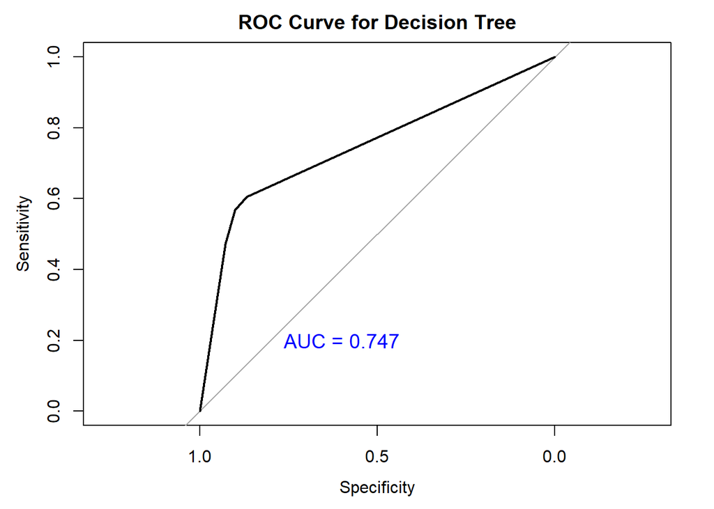

```r
tree_auc_value <- auc(tree_roc_result)
plot(tree_roc_result, main = "ROC Curve for Decision Tree")
text(x = 0.6, y = 0.2, labels = paste("AUC =", round(tree_auc_value, 3)), cex = 1.2, col = "blue")
```

— Random Forest —

```r
rf_model <- randomForest(y ~ ., data = train_tree, ntree=500, mtry=3, importance=TRUE)
test_tree$predictions <- predict(rf_model, newdata = test_tree)

confusionMatrix <- table(Predicted = test_tree$predictions, Actual = test_tree$y)
print(confusionMatrix)
```

```
##          Actual
## Predicted   no  yes
##       no  8539  572
##       yes  598  588
```

```r
calculate_metrics(confusionMatrix)
```

```
##               Metric      Value
##             Accuracy 0.88637467
##  False Positive Rate 0.06278125
##  False Negative Rate 0.50421585
##            Precision 0.50689655
##               Recall 0.49578415
##             F1 Score 0.50127877
```

Similar result

```r
importance <- importance(rf_model)
print(importance)
```

```
##                      no       yes MeanDecreaseAccuracy MeanDecreaseGini
## age            60.40029 103.95238            103.89915        611.32219
## job            87.22864  92.64135            116.38332        512.55929
## marital        43.77604  73.62021             75.78238        169.34148
## education      58.38271 114.59624            108.14828        357.54042
## default        23.08931  48.65578             48.45806         77.21979
## housing        44.25992  87.32579             85.23854        140.03825
## loan           36.50556  77.61847             75.93474        107.60722
## contact        12.05369  50.46926             26.99422         99.61224
## month          31.39976  22.42469             40.10050        289.78823
## day_of_week    53.14106 106.83421             98.60018        322.26425
## campaign       50.23645 107.15428            105.78984        316.72629
## pdays          16.38020  37.04713             34.39014        241.15765
## previous       12.15986  28.96849             21.10850        119.54961
## poutcome       19.87869  29.74654             30.61276        206.63649
## emp.var.rate   22.18399  17.70633             25.51583        323.21821
## cons.price.idx 22.79107  25.72731             27.90900        206.50817
## cons.conf.idx  22.45501  27.53163             30.60094        231.67416
## euribor3m      31.19150  46.76162             48.18722        873.20127
## nr.employed    23.30117  27.48627             31.41427        554.78034
```

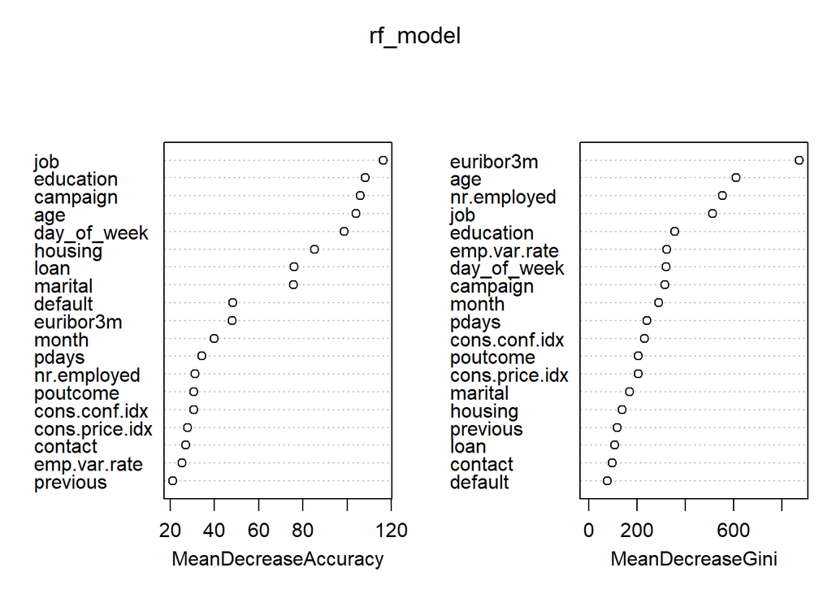

```r
# Plot variable importance
varImpPlot(rf_model)
```

Let’s see if fine-tuning can make this better

```r
help(train)
```

```
## 打开httpd帮助服务器… 好了
```

```r
train_control <- trainControl(method="cv", number=5)

# Train the model with tuning grid
tuned_model <- train(y ~ ., data=train_tree, method="rf", trControl=train_control,
                     tuneGrid=data.frame(mtry=c(2, 3, 4)),
                     ntree=300)
```

```r
test_tree$predictions <- predict(tuned_model, newdata = test_tree)
confusionMatrix <- table(Predicted = test_tree$predictions, Actual = test_tree$y)
print(confusionMatrix)
```

```
##          Actual
## Predicted   no  yes
##       no  8441  543
##       yes  696  617
```

```r
calculate_metrics(confusionMatrix)
```

```
##               Metric      Value
##             Accuracy 0.87967369
##  False Positive Rate 0.06044078
##  False Negative Rate 0.53008378
##            Precision 0.53189655
##               Recall 0.46991622
##             F1 Score 0.49898908
```

Okay… No significant difference.

```r
test_tree$rf_prob_predictions <- predict(rf_model, newdata = test_tree, type = "prob")
test_tree$rf_positive_probs <- test_tree$rf_prob_predictions[, "yes"]
rf_roc_result <- roc(test_tree$y, test_tree$rf_positive_probs)
```

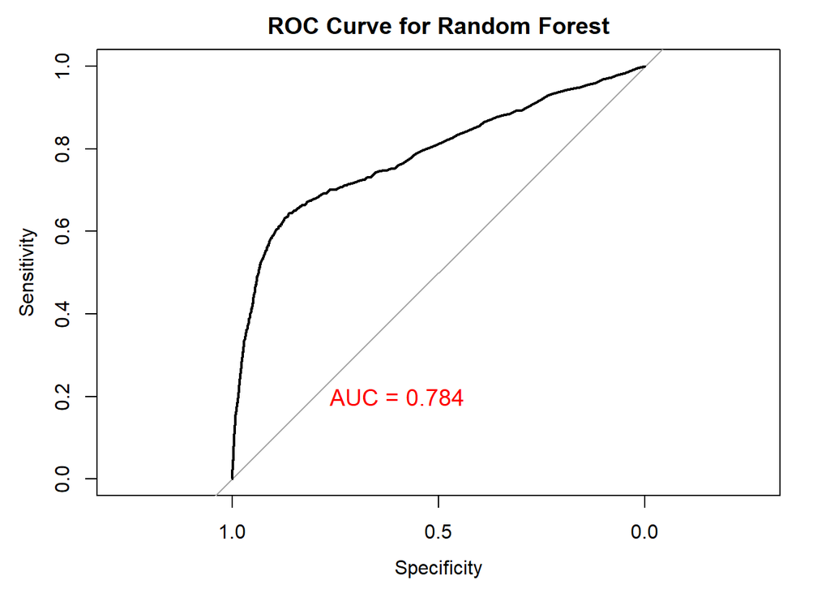

```r
rf_auc_value <- auc(rf_roc_result)
plot(rf_roc_result, main = "ROC Curve for Random Forest")
text(x = 0.6, y = 0.2, labels = paste("AUC =", round(rf_auc_value, 3)), cex = 1.2, col = "red")
```

— RNN —

Since RNN is sensitive to scale, we will be using the training_balanced_scaled

First covert y to categorical

Also please note this requires a python environment with keras

```r
library(reticulate)
use_python("C:\\Users\\16784\\AppData\\Local\\Programs\\Python\\Python311", required = TRUE) # set path to your python dir with keras
# or use keras::install_keras(tensorflow = "default") to install keras in the virtual environment
train_labels <- to_categorical(train_balanced_scaled$y)
test_labels <- to_categorical(test_set_scaled$y)
```

Convert to matrix for training

```r
train_data <- as.matrix(train_balanced_scaled[, -which(names(train_balanced_scaled) == "y")])
test_data <- as.matrix(test_set_scaled[, -which(names(test_set_scaled) == "y")])
```

```r
# Define F1 Score as a custom metric
f1_score <- function(y_true, y_pred) {
  y_pred <- k_cast(k_greater(y_pred, 0.5), 'float32')
  tp <- k_sum(y_true * y_pred)
  precision <- tp / (k_sum(y_pred) + k_epsilon())
  recall <- tp / (k_sum(y_true) + k_epsilon())
  f1_val <- 2 * (precision * recall) / (precision + recall + k_epsilon())
  return(f1_val)
}

# Add custom F1 Score metric to the model
metric_f1_score <- custom_metric("f1_score", f1_score)
```

```r
# Design the model
# Only 2 computing layers due to overfitting, it turns out we don't really need much complexity
model <- keras_model_sequential() %>%
  layer_dense(units = 8, activation = 'relu', input_shape = c(27), kernel_regularizer = regularizer_l2(0.01)) %>%
  layer_dropout(rate = 0.3) %>% # Adding dropout layer since we observed overfitting in a few epochs
  layer_dense(units = 2, activation = 'softmax') # 2 neurons output layer since we have 2 classes

model %>% compile(
  loss = 'binary_crossentropy',
  optimizer = optimizer_rmsprop(learning_rate = 0.00001),
  metrics = list(metric_auc(curve = "ROC"), metric_f1_score)
)
```

```r
# Fit the model
history <- model %>% fit(
  train_data,
  train_labels,
  epochs = 10,
  batch_size = 128,
  validation_split = 0.2
)
```

```
## 125/125 - 1s - loss: 1.0248 - auc: 0.5298 - f1_score: 0.5410 - val_loss: 0.9944 - val_auc: 0.5030 - val_f1_score: 0.5142 - 722ms/epoch - 6ms/step
## 125/125 - 0s - loss: 1.0155 - auc: 0.5350 - f1_score: 0.5442 - val_loss: 0.9966 - val_auc: 0.4984 - val_f1_score: 0.5095 - 138ms/epoch - 1ms/step
## 125/125 - 0s - loss: 1.0115 - auc: 0.5363 - f1_score: 0.5451 - val_loss: 0.9986 - val_auc: 0.4944 - val_f1_score: 0.5039 - 128ms/epoch - 1ms/step
## 125/125 - 0s - loss: 1.0023 - auc: 0.5439 - f1_score: 0.5565 - val_loss: 1.0009 - val_auc: 0.4902 - val_f1_score: 0.4993 - 130ms/epoch - 1ms/step
## 125/125 - 0s - loss: 0.9961 - auc: 0.5482 - f1_score: 0.5567 - val_loss: 1.0030 - val_auc: 0.4858 - val_f1_score: 0.4941 - 127ms/epoch - 1ms/step
## 125/125 - 0s - loss: 0.9907 - auc: 0.5487 - f1_score: 0.5560 - val_loss: 1.0050 - val_auc: 0.4818 - val_f1_score: 0.4912 - 128ms/epoch - 1ms/step
## 125/125 - 0s - loss: 0.9820 - auc: 0.5568 - f1_score: 0.5617 - val_loss: 1.0070 - val_auc: 0.4777 - val_f1_score: 0.4841 - 130ms/epoch - 1ms/step
## 125/125 - 0s - loss: 0.9797 - auc: 0.5592 - f1_score: 0.5659 - val_loss: 1.0091 - val_auc: 0.4734 - val_f1_score: 0.4817 - 125ms/epoch - 997us/step
## 125/125 - 0s - loss: 0.9733 - auc: 0.5609 - f1_score: 0.5654 - val_loss: 1.0112 - val_auc: 0.4693 - val_f1_score: 0.4773 - 126ms/epoch - 1ms/step
## 125/125 - 0s - loss: 0.9670 - auc: 0.5692 - f1_score: 0.5782 - val_loss: 1.0134 - val_auc: 0.4651 - val_f1_score: 0.4758 - 129ms/epoch - 1ms/step
```

No matter how we perform hyperparameter tuning, the validation loss and val F1 score just won’t improve weith more training. Although the model is a failure, it has some important implications: there is basically no more “hidden” information remain uncaptured by our simpler models. Increasing the complexity would only make things worse. The imbalanced initial dataset is the real bottleneck of the prediction model.

— XGboost —

Define params

```r
params <- list(
  booster = "gbtree",
  objective = "binary:logistic",
  eta = 0.1,
  max_depth = 6,
  subsample = 0.5,
  colsample_bytree = 0.5
)
```

Train the model

```r
xgb_model <- xgb.train(params = params, data = dtrain, nrounds = 100, watchlist = list(eval = dtest), early_stopping_rounds = 10)
```

[output not shown]

[output not shown]

Using a 0.5 cutoff

```r
pred <- predict(xgb_model, dtest)
binary_preds <- ifelse(pred > 0.5, 1, 0)
actual_labels <- getinfo(dtest, "label")  # Get the actual labels from the DMatrix
conf_matrix <- confusionMatrix(factor(binary_preds, levels = c(0, 1)), factor(actual_labels, levels = c(0, 1)))
print(conf_matrix)
```

```
## Confusion Matrix and Statistics
##
##           Reference
## Prediction    0    1
##          0 8279  842
##          1  821  355
##
##                Accuracy : 0.8385
##                  95% CI : (0.8312, 0.8456)
##     No Information Rate : 0.8838
##     P-Value [Acc > NIR] : 1.0000
##
##                   Kappa : 0.2079
##
##  Mcnemar's Test P-Value : 0.6238
##
##             Sensitivity : 0.9098
##             Specificity : 0.2966
##          Pos Pred Value : 0.9077
##          Neg Pred Value : 0.3019
##              Prevalence : 0.8838
##          Detection Rate : 0.8040
##    Detection Prevalence : 0.8858
##       Balanced Accuracy : 0.6032
##
##        'Positive' Class : 0
##
```

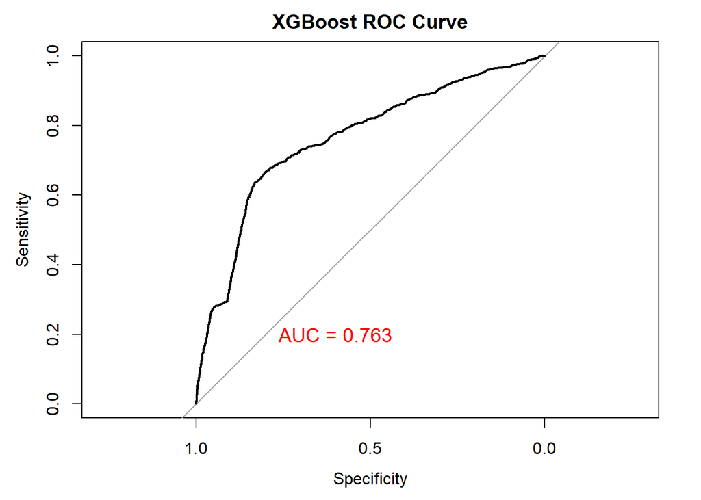

```r
xgb_roc_curve <- roc(response = actual_labels, predictor = pred)
xgb_auc_value <- auc(xgb_roc_curve)
plot(xgb_roc_curve, main = "XGBoost ROC Curve")
text(x = 0.6, y = 0.2, labels = paste("AUC =", round(xgb_auc_value, 3)), cex = 1.2, col = "red")
```

Finally, a plot aggregate the ROC curves of my models

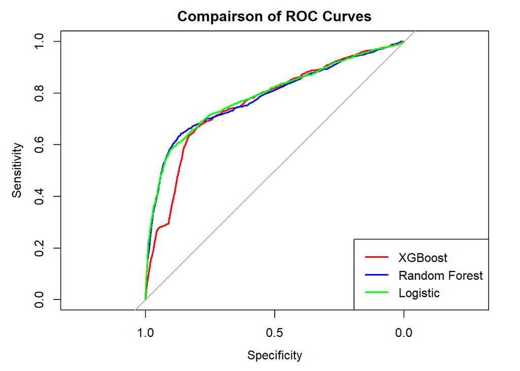

```r
plot(xgb_roc_curve, main = "Compairson of ROC Curves", col = "red", lwd = 2)
lines(rf_roc_result, col = "blue", lwd = 2)
lines(log_roc_result, col = "green", lwd = 2)
legend("bottomright", legend = c("XGBoost", "Random Forest", "Logistic"), col = c("red", "blue", "green"), lwd = 2)
```